# Assignment 5: Data Visualization

Jinglin Zhang

Spring 2023

## OVERVIEW

This exercise accompanies the lessons in Environmental Data Analytics on Data Visualization

## Directions

1. Rename this file `<FirstLast>_A05_DataVisualization.Rmd` (replacing `<FirstLast>` with your first and last name).
2. Change “Student Name” on line 3 (above) with your name.
3. Work through the steps, **creating code and output** that fulfill each instruction.
4. Be sure your code is tidy; use line breaks to ensure your code fits in the knitted output.
5. Be sure to **answer the questions** in this assignment document.
6. When you have completed the assignment, **Knit** the text and code into a single PDF file.

## Set up your session

1. Set up your session. Load the tidyverse, lubridate, here & cowplot packages, and verify your home directory. Upload the NTL-LTER processed data files for nutrients and chemistry/physics for Peter and Paul Lakes (use the tidy `NTL-LTER_Lake_Chemistry_Nutrients_PeterPaul_Processed.csv` version) and the processed data file for the Niwot Ridge litter dataset (use the `NEON_NIWO_Litter_mass_trap_Processed.csv` version).
2. Make sure R is reading dates as date format; if not change the format to date.

```r
#1
library(tidyverse)
library(lubridate)
library(here)
```

```r
library(cowplot)
getwd()
```

```
## [1] "C:/Users/wwwla/Documents/EDA-Spring2023"
```

```r
lake.chem.nut <- read.csv("~/EDA-Spring2023/Data/Processed_KEY/NTL-LTER_Lake_Chemistry_Nutrients_PeterPaul_Processed.csv",stringsAsFactors = TRUE)
litter.mass <- read.csv("~/EDA-Spring2023/Data/Processed/NEON_NIWO_Litter_mass_trap_Processed.csv",stringsAsFactors = TRUE)
#2
is.Date(lake.chem.nut$sampledate)
```

```
## [1] FALSE
```

```r
is.Date(litter.mass$collectDate)
```

```
## [1] FALSE
```

```r
lake.chem.nut$sampledate <- ymd(lake.chem.nut$sampledate)
litter.mass$collectDate <- ymd(litter.mass$collectDate)
is.Date(lake.chem.nut$sampledate)
```

```
## [1] TRUE
```

```r
is.Date(litter.mass$collectDate)
```

```
## [1] TRUE
```

## Define your theme

3. Build a theme and set it as your default theme. Customize the look of at least two of the following:
- Plot background
- Plot title
- Axis labels
- Axis ticks/gridlines
- Legend

```r
#3
mytheme <- theme(
        plot.background = element_rect(fill = "lightgray"),
        plot.title = element_text(size = 16, face = "bold"),
        axis.text = element_text(color = "black"),
        axis.line = element_line(colour = "black", size = 0.5),
        legend.position = "top",
        legend.text = element_text(size = 10)
        )
theme_set(mytheme)
```

## Create graphs

For numbers 4-7, create ggplot graphs and adjust aesthetics to follow best practices for data visualization. Ensure your theme, color palettes, axes, and additional aesthetics are edited accordingly.

4. [NTL-LTER] Plot total phosphorus (`tp_ug`) by phosphate (`po4`), with separate aesthetics for Peter and Paul lakes. Add a line of best fit and color it black. Adjust your axes to hide extreme values (hint: change the limits using `xlim()` and/or `ylim()`).

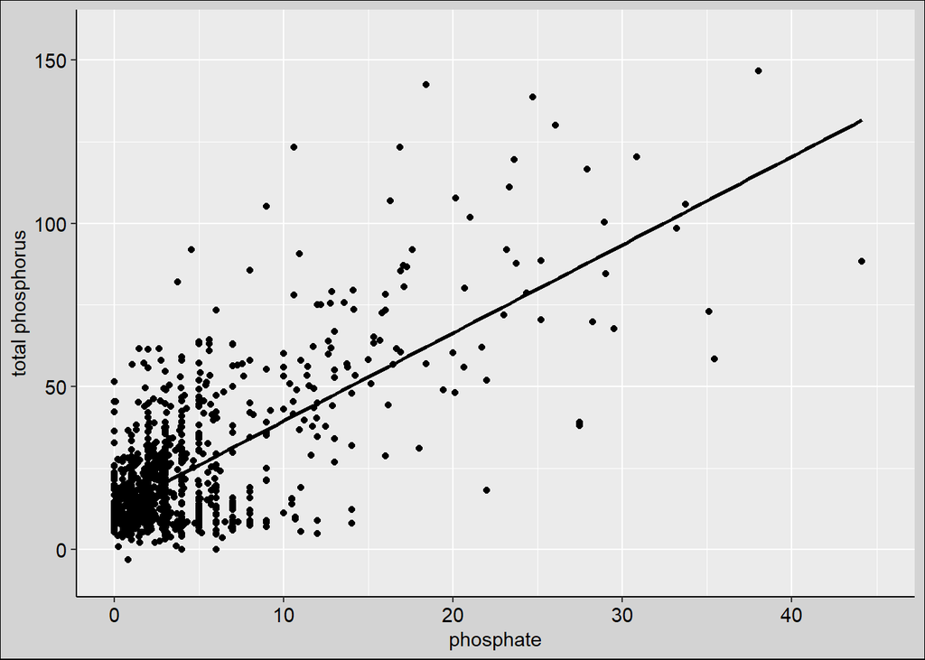

```r
#4
ggplot(lake.chem.nut, aes(x = po4, y = tp_ug)) +
  geom_point() +
  xlim(0,45) +
  labs(x = "phosphate", y = "total phosphorus") +
  geom_smooth(method = lm, se = FALSE, colour = "black")
```

5. [NTL-LTER] Make three separate boxplots of (a) temperature, (b) TP, and (c) TN, with month as the x axis and lake as a color aesthetic. Then, create a cowplot that combines the three graphs. Make sure that only one legend is present and that graph axes are aligned.

Tip: R has a build in variable called `month.abb` that returns a list of months;see https://r-lang.com/month-abb-in-r-with-example

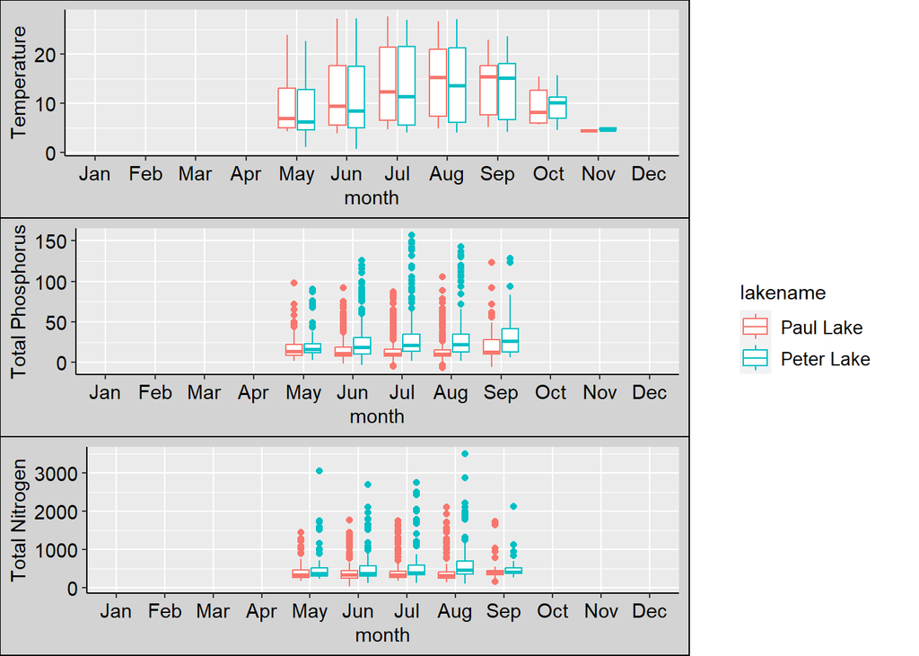

```r
#5
lake.T <- ggplot(lake.chem.nut,
                 aes(x = factor(month, levels = 1:12, labels = month.abb),
                     y = temperature_C, color = lakename)) +
  scale_x_discrete(drop = FALSE) +
  geom_boxplot() +
  labs(x = "month", y = "Temperature")

lake.TP <- ggplot(lake.chem.nut,
                 aes(x = factor(month, levels = 1:12, labels = month.abb),
                     y = tp_ug, color = lakename)) +
  scale_x_discrete(drop = FALSE) +
  geom_boxplot() +
  labs(x = "month", y = "Total Phosphorus") +
  theme(legend.position = "none")

lake.TN <- ggplot(lake.chem.nut,
                 aes(x = factor(month, levels = 1:12, labels = month.abb),
                     y = tn_ug, color = lakename)) +
  scale_x_discrete(drop = FALSE) +
  geom_boxplot() +
  labs(x = "month", y = "Total Nitrogen") +
  theme(legend.position = "none")

legend <- get_legend(
  lake.T +
  guides(color = guide_legend(nrow = 2)) +
  theme(legend.position = "right")
)
plot1 <- plot_grid(lake.T + theme(legend.position = "none"),
          lake.TP + theme(legend.position = "none"),
          lake.TN + theme(legend.position = "none"),
          nrow = 3)
plot_grid(plot1, legend, nrow = 1, rel_widths = c(3, 1))
```

Question: What do you observe about the variables of interest over seasons and between lakes?

> Answer: during the summer, the temperature of two lakes are similar, but TP and TN in Peter Lake are generally higher than them in Paul Lake.
6. [Niwot Ridge] Plot a subset of the litter dataset by displaying only the “Needles” functional group. Plot the dry mass of needle litter by date and separate by NLCD class with a color aesthetic. (no need to adjust the name of each land use)
7. [Niwot Ridge] Now, plot the same plot but with NLCD classes separated into three facets rather than separated by color.

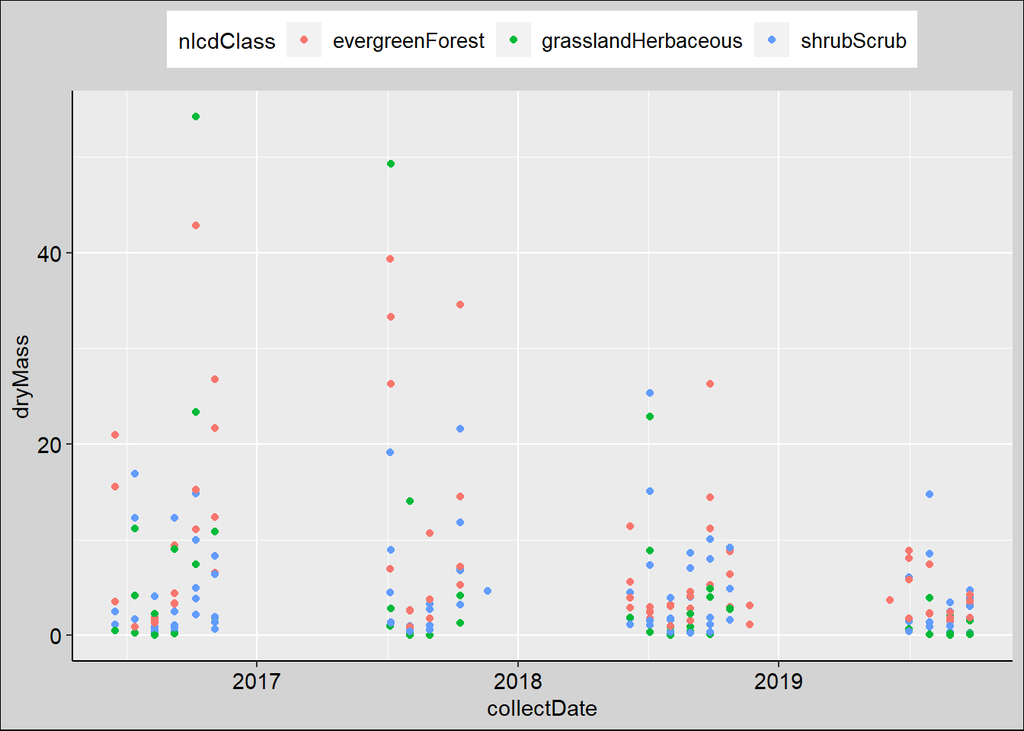

```r
#6
litter.mass %>%
  filter(functionalGroup == "Needles") %>%
  ggplot(aes(x = collectDate, y = dryMass, color = nlcdClass)) +
  geom_point()
```

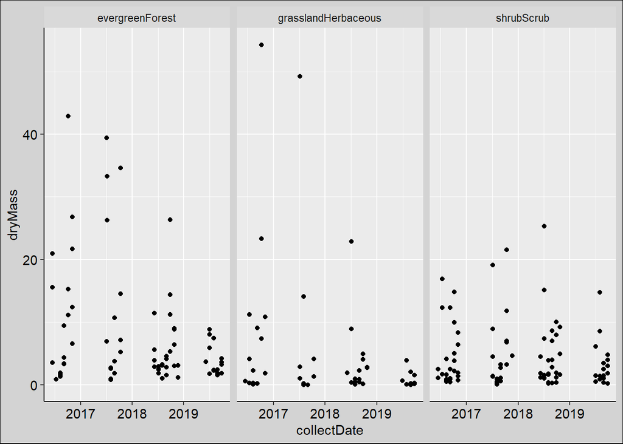

```r
#7
litter.mass %>%
  filter(functionalGroup == "Needles") %>%
  ggplot(aes(x = collectDate, y = dryMass)) +
  geom_point() +
  facet_wrap(vars(nlcdClass))
```

Question: Which of these plots (6 vs. 7) do you think is more effective, and why?

> Answer: the second one, because it shows the trend of drymass more clearly than the 6th, there are too many points appear in a single grapth that make me hard to catch informations.